# GitHub Recommender

Whenever one starts a new project using open source software, there is usually a lot of research to find the most adequate projects that attempt to solve the problem at hand. Different projects that help solve a particular problem tend to share a shared community of users, be it by common stars, comments in issues or even commits in code.

There is already a project on GitHub that tackles this problem [1](https://github.com/anvaka/ghindex) by analyzing common stargazers to find related projects. The proposal of this project is to build a system that takes into account not only common stargazers, but also issue created by the uses in both platforms.

In order to validate this hypothesis, we analyze a handful of related machine learning projects. By using the available BigQuery githubarchive data set [2](https://bigquery.cloud.google.com/table/githubarchive), we fetch some issue comment and watch (stars) events in order to analyze, using the following query:

```
SELECT repo.name AS repository_name,
  type,
  date(created_at) AS event_date, count(*) AS total_events
FROM `githubarchive.day.20*`
WHERE _TABLE_SUFFIX BETWEEN '100101' AND '180630'
AND type IN ('WatchEvent', 'IssueCommentEvent')
AND repo.name IN (
  'tensorflow/tensorflow',
  'BVLC/caffe',
  'google/deepdream',
  'hangtwenty/dive-into-machine-learning',
  'keras-team/keras',
  'scikit-learn/scikit-learn'
)
GROUP BY date(created_at), repo.name, type
```

Next, we do some analysis using an R script.

```r
require(dplyr)
require(readr)
require(tidyr)
```

```r
require(ggplot2)
github <- read_csv("github.csv")
cum_github <- github %>%
  group_by(repository_name, type) %>%
  arrange(repository_name, type, event_date) %>%
  mutate(cum_total = cumsum(total_events)) %>%
  rename(event_type=type)
```

In the first plot, we can see the cumulative star and issue comments for each of the projects. In the top graph we see the total issue comments of the projects, whereas in the bottom graph we see the total stars for each project. The interesting relation we find here is the `BVLC/caffe` and `scikit-learn/scikit-learn` grow at a similar rate in the stargazers graph (WatchEvent), and have started getting popular at the same period (circa beginning of 2015).

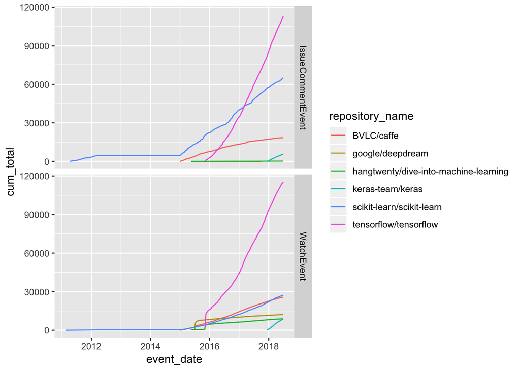

```r
qplot(event_date, cum_total, color = repository_name, facets = event_type~.,
      data = cum_github, geom = "line")
```

The second plot shows just the starred and issue comments activities for each day, therefore serving as a proxy for the daily activity of the project. In the top graph we see the issue comment activity, in the bottom graph we see the starred activity. We see there is a similar trend in some of the curves. In the comments graph, the `BVLC/caffe`, `scikit-learn/scikit-learn` and `tensorflow/tensorflow` seem to follow a similar trend, which suggest a related active engagement in each of these projects. In the stars graph, we find a similar trend between `BVLC/caffe` and `scikit-learn/scikit-learn`, which suggests a related discovery of these two projects. We notice there is activity in the `google/deepdream` and `hangtwenty/dive-into-machine-learning`, as opposed to almost none in the issues graph. This makes sense if we consider that these two projects are just text reference repositories, and not software in active development. Therefore, they tend to not get much activity.

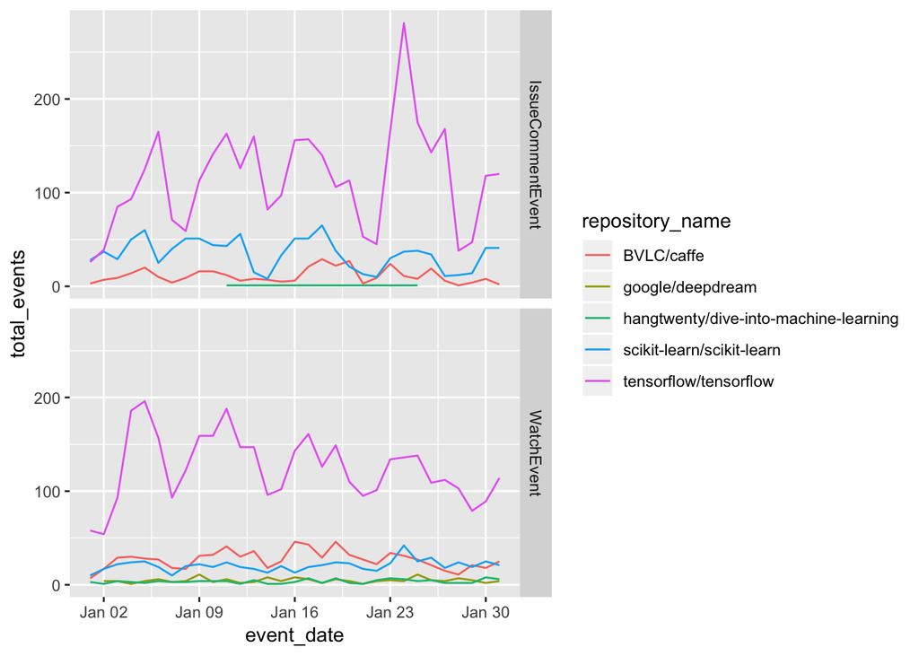

```r
qplot(event_date, total_events, color = repository_name, facets = type~., data = github %>%
  filter(event_date >= '2017-01-01' & event_date <= '2017-01-31'), geom = "line")
```

We try next a different approach, searching for all Tensorflow users with a minimum of 3 comments, look for projects that have at least 100 comments in a given period, for which the Tensorflow users have also commented. We execute the following query:

```
WITH github_days AS (
  SELECT actor.login AS login,
    repo.url AS repo_url,
    date(created_at) AS event_date,
    type
  FROM `githubarchive.day.20*`
  WHERE _TABLE_SUFFIX BETWEEN '140101' AND '180630'
  AND type IN ('WatchEvent', 'IssueCommentEvent')
), tensorflow_activity AS (
  SELECT login
  FROM github_days
  WHERE type IN ('IssueCommentEvent')
  AND repo_url IN (
    'https://api.github.com/repos/tensorflow/tensorflow'
  )
  GROUP BY login
  HAVING count(*) >= 3
), popular_projects AS (
  SELECT repo_url
  FROM github_days
  WHERE type IN ('IssueCommentEvent')
  GROUP BY repo_url
  HAVING count(*) >= 100
)

SELECT repo_url, event_date, count(*) AS total_events
FROM github_days
WHERE login IN (SELECT login FROM tensorflow_activity)
AND repo_url IN (SELECT repo_url FROM popular_projects)
AND type = 'IssueCommentEvent'
GROUP BY repo_url, event_date
```

Finally, using R, we look look at the rank of the projects with most comments.

```r
tensorflow_activity <- read_csv("tensorflowactivity.csv")
most_similar_projects <- tensorflow_activity %>%
  group_by(repo_url) %>%
  summarize(total_comments = sum(total_events)) %>%
  arrange(desc(total_comments)) %>%
  head(10)

knitr::kable(most_similar_projects)
```

| repo_url | total_comments |
| --- | --- |
| https://api.github.com/repos/tensorflow/tensorflow | 101133 |
| https://api.github.com/repos/google-test/signcla-probe-repo | 30676 |
| https://api.github.com/repos/bazelbuild/bazel | 11560 |
| https://api.github.com/repos/fchollet/keras | 9654 |
| https://api.github.com/repos/NixOS/nixpkgs | 8108 |
| https://api.github.com/repos/tensorflow/models | 7805 |
| https://api.github.com/repos/grpc/grpc | 6370 |
| https://api.github.com/repos/apache/spark | 5437 |
| https://api.github.com/repos/mholt/caddy | 4901 |
| https://api.github.com/repos/dask/dask | 4642 |

The goal of the project is to create a similar projects recommendation system that takes into account both stars and issues in the project, and, even though the time available for research is very short, we found some interesting findings. For the project, I want to explore other possibilities, such as using a graph database to find unexpected correlations, as well as I intend to build a self feeding system, that will update itself based on new data provided by the GitHub archive.